# Online Ad Analysis

Joseph Kirika

02/07/2021

## Defining the Question

### a) Specifying the Question

1. To identify which individuals were most likely to click on an online ad related to a cryptography course.

ii)To predict whether or not an individual clicks on the online ad

### b) Defining the Metric for Success

To be able to ran thorough data analysis so as to reveal the underlying information on the various characteristics of people who are most likely to click on the ad. Furthermore to carry out analysis that would aid in forming strategies that would used as a tool to capture more target population.Furthermore, coming up with a supervised learning model that predicts whether (classification) an individual clicks on the online ad. the model will be evaluated by an accuracy score

### c) Understanding the context

A Kenyan entrepreneur created an online cryptography course and wanted to advertise it on her blog. She targeted audiences originating from various countries. In the past, she ran ads to advertise a related course on the same blog and collected data in the process. She then wanted to identify which individuals were most likely to click on her ads.

### d) Recording the Experimental Design

- Reading the dataset
- Cleanig and dealing with anomalies to ensure that the quality of the data is upto the task
- Exploring the given dataset using univariate and bivariate techniques
- Highlighting some of the insights given
- cross check the various supervised learning models that best predicts our data
- Attempting to challenge the solutions given
- Providing some conclusions and recommendations

### e) Data Relevance

The data relevance ought to be evaluated against the metric of success after analysis. The following is a list of variable names describing the dataset given:

- Daily Time Spent on Site
- Age
- Area Income
- Daily Internet Usage
- Ad Topic Line
- City
- Male
- Country
- Timestamp
- Clicked on Ad

## Importing And Previewing The Data

### Importing the data

```r
# reading the dataset
df = read.csv('http://bit.ly/IPAdvertisingData')
```

### Previewing the data

```r
# checking the first 6 rows of the dataset
head(df)
```

```
##   Daily.Time.Spent.on.Site Age Area.Income Daily.Internet.Usage
## 1                    68.95  35    61833.90               256.09
## 2                    80.23  31    68441.85               193.77
## 3                    69.47  26    59785.94               236.50
## 4                    74.15  29    54806.18               245.89
## 5                    68.37  35    73889.99               225.58
## 6                    59.99  23    59761.56               226.74
##                           Ad.Topic.Line           City Male    Country
## 1    Cloned 5thgeneration orchestration    Wrightburgh    0    Tunisia
## 2    Monitored national standardization      West Jodi    1      Nauru
## 3      Organic bottom-line service-desk       Davidton    0 San Marino
## 4 Triple-buffered reciprocal time-frame West Terrifurt    1      Italy
## 5         Robust logistical utilization   South Manuel    0    Iceland
## 6       Sharable client-driven software      Jamieberg    1     Norway
##             Timestamp Clicked.on.Ad
## 1 2016-03-27 00:53:11             0
## 2 2016-04-04 01:39:02             0
## 3 2016-03-13 20:35:42             0
## 4 2016-01-10 02:31:19             0
## 5 2016-06-03 03:36:18             0
## 6 2016-05-19 14:30:17             0
```

```r
# checking the last 6 rows of the dataset
tail(df)
```

```
##      Daily.Time.Spent.on.Site Age Area.Income Daily.Internet.Usage
## 995                     43.70  28    63126.96               173.01
## 996                     72.97  30    71384.57               208.58
## 997                     51.30  45    67782.17               134.42
## 998                     51.63  51    42415.72               120.37
## 999                     55.55  19    41920.79               187.95
## 1000                    45.01  26    29875.80               178.35
##                             Ad.Topic.Line          City Male
## 995         Front-line bifurcated ability  Nicholasland    0
## 996         Fundamental modular algorithm     Duffystad    1
## 997       Grass-roots cohesive monitoring   New Darlene    1
## 998          Expanded intangible solution South Jessica    1
## 999  Proactive bandwidth-monitored policy   West Steven    0
## 1000      Virtual 5thgeneration emulation   Ronniemouth    0
##                     Country           Timestamp Clicked.on.Ad
## 995                 Mayotte 2016-04-04 03:57:48             1
## 996                 Lebanon 2016-02-11 21:49:00             1
## 997  Bosnia and Herzegovina 2016-04-22 02:07:01             1
## 998                Mongolia 2016-02-01 17:24:57             1
## 999               Guatemala 2016-03-24 02:35:54             0
## 1000                 Brazil 2016-06-03 21:43:21             1
```

```r
# getting the information of the data frame
str(df)
```

```
## 'data.frame':    1000 obs. of  10 variables:
##  $ Daily.Time.Spent.on.Site: num  69 80.2 69.5 74.2 68.4 ...
##  $ Age                     : int  35 31 26 29 35 23 33 48 30 20 ...
##  $ Area.Income             : num  61834 68442 59786 54806 73890 ...
##  $ Daily.Internet.Usage    : num  256 194 236 246 226 ...
##  $ Ad.Topic.Line           : chr  "Cloned 5thgeneration orchestration" "Monitored national standardization" "Organic bottom-line service-desk" "Triple-buffered reciprocal time-frame" ...
##  $ City                    : chr  "Wrightburgh" "West Jodi" "Davidton" "West Terrifurt" ...
##  $ Male                    : int  0 1 0 1 0 1 0 1 1 1 ...
##  $ Country                 : chr  "Tunisia" "Nauru" "San Marino" "Italy" ...
##  $ Timestamp               : chr  "2016-03-27 00:53:11" "2016-04-04 01:39:02" "2016-03-13 20:35:42" "2016-01-10 02:31:19" ...
##  $ Clicked.on.Ad           : int  0 0 0 0 0 0 0 1 0 0 ...
```

```r
# checking the shape of the dataset
dim(df)
```

```
## [1] 1000   10
```

## Data Cleaning

```r
#editing the column names to lowercase
names(df) <- tolower(names(df))
names(df)
```

```
##  [1] "daily.time.spent.on.site" "age"
##  [3] "area.income"              "daily.internet.usage"
##  [5] "ad.topic.line"            "city"
##  [7] "male"                     "country"
##  [9] "timestamp"                "clicked.on.ad"
```

```r
# checking for the sum of null values in each column

colSums(is.na(df))
```

```
## daily.time.spent.on.site                      age              area.income
##                        0                        0                        0
##     daily.internet.usage            ad.topic.line                     city
##                        0                        0                        0
##                     male                  country                timestamp
##                        0                        0                        0
##            clicked.on.ad
##                        0
```

```r
# Checking for duplicated data
df[duplicated(df), ]
```

```
##  [1] daily.time.spent.on.site age                      area.income
##  [4] daily.internet.usage     ad.topic.line            city
##  [7] male                     country                  timestamp
## [10] clicked.on.ad
## <0 rows> (or 0-length row.names)
```

- There are no null values
- There are no duplicated values

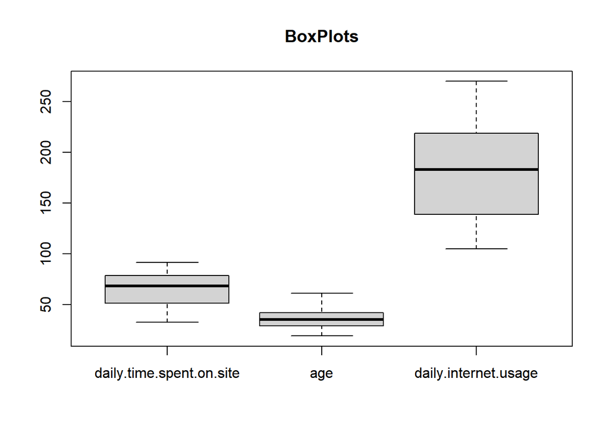

```r
# checking for outliers precisely on the continuous variables

cont_cols <- df[c('daily.time.spent.on.site','age',               'daily.internet.usage')]

boxplot(cont_cols, main='BoxPlots')
```

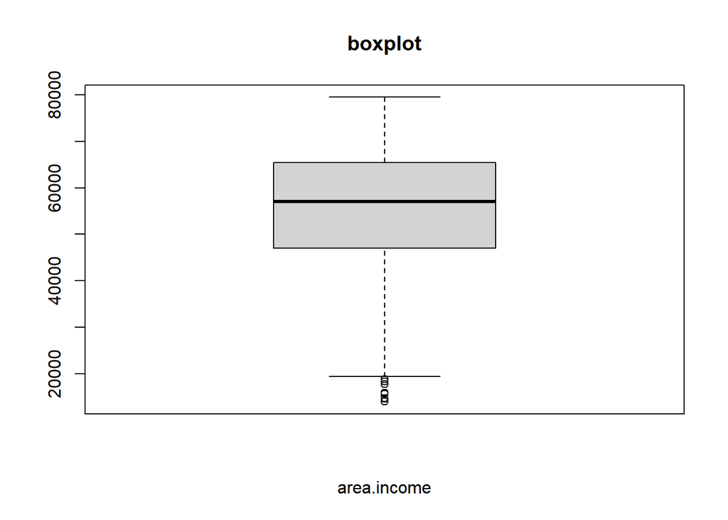

```r
# checking outliers for the area outcome
boxplot(df$area.income,xlab='area.income', main='boxplot')
```

> - outliers are evident in the area income variable, this may be due to disparities in currencies between different countries

## Exploratory Data Analysis

### Univariate Analysis

```r
summary(df)
```

```
##  daily.time.spent.on.site      age         area.income    daily.internet.usage
##  Min.   :32.60            Min.   :19.00   Min.   :13996   Min.   :104.8
##  1st Qu.:51.36            1st Qu.:29.00   1st Qu.:47032   1st Qu.:138.8
##  Median :68.22            Median :35.00   Median :57012   Median :183.1
##  Mean   :65.00            Mean   :36.01   Mean   :55000   Mean   :180.0
##  3rd Qu.:78.55            3rd Qu.:42.00   3rd Qu.:65471   3rd Qu.:218.8
##  Max.   :91.43            Max.   :61.00   Max.   :79485   Max.   :270.0
##  ad.topic.line          city                male         country
##  Length:1000        Length:1000        Min.   :0.000   Length:1000
##  Class :character   Class :character   1st Qu.:0.000   Class :character
##  Mode  :character   Mode  :character   Median :0.000   Mode  :character
##                                        Mean   :0.481
##                                        3rd Qu.:1.000
##                                        Max.   :1.000
##   timestamp         clicked.on.ad
##  Length:1000        Min.   :0.0
##  Class :character   1st Qu.:0.0
##  Mode  :character   Median :0.5
##                     Mean   :0.5
##                     3rd Qu.:1.0
##                     Max.   :1.0
```

> Insight: * The above output shows the various quantiles,the maximum and minimums of the various variables given

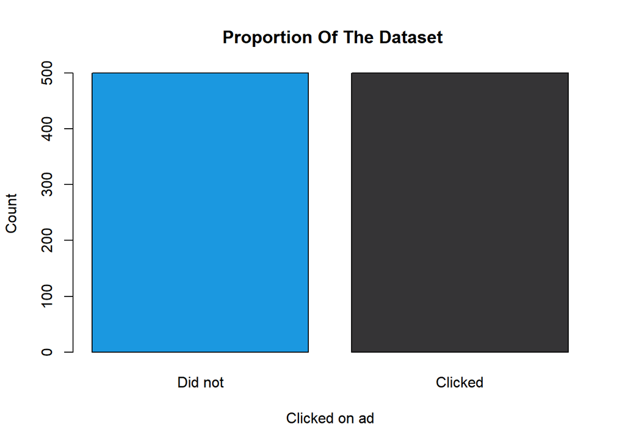

```r
#BarChart for gender
# x-axis values
clicked <- table(df$clicked.on.ad)
# plotting the barplot for gender

barplot(clicked,names.arg = c("Did not","Clicked"), col = c("#1b98e0", "#353436"), xlab='Clicked on ad', ylab ='Count', main = ' Proportion Of The Dataset')
```

> * The data seemed to be well balanced

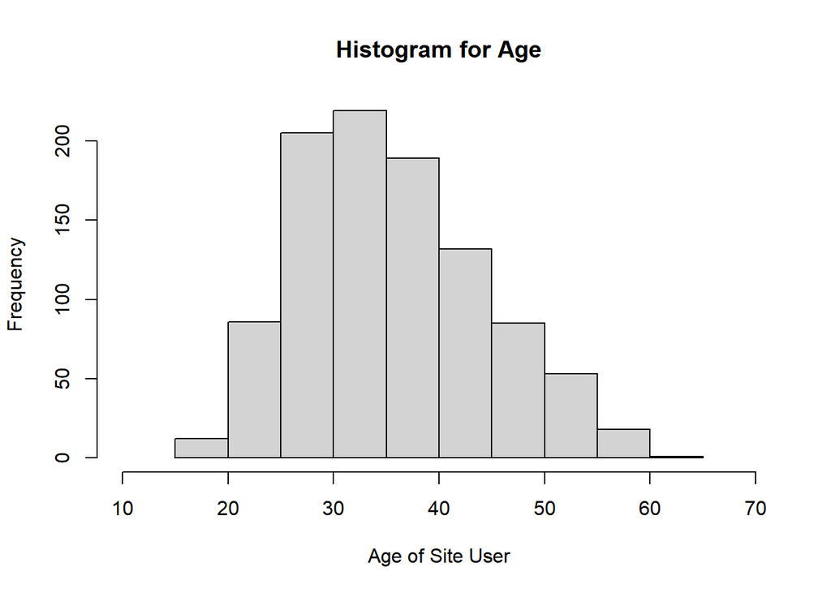

```r
#Histogram of age
hist(df$age,xlim = c(10,70) ,xlab ='Age of Site User', main ='Histogram for Age')
```

> * The distribution of age is between 15-65 with most people between ages 25 and 40 years

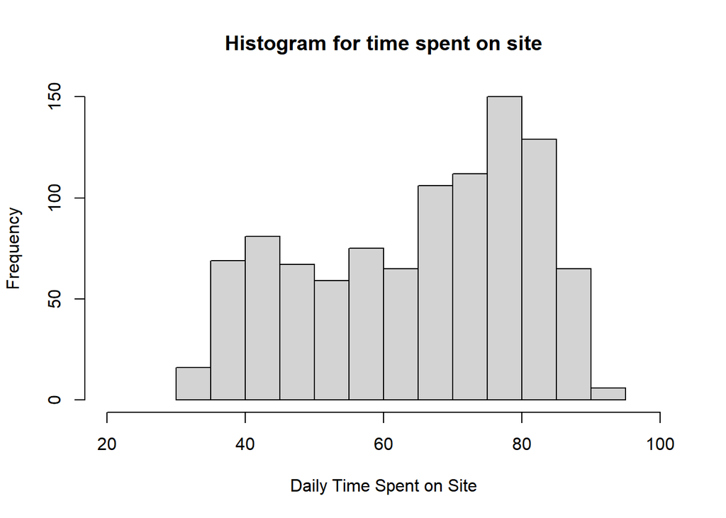

```r
hist(df$daily.time.spent.on.site,xlim = c(20,100), xlab ='Daily Time Spent on Site', main ='Histogram for time spent on site')
```

> * seemingly the amount spent on site by most online profiles is about 65 to 85 minutes(assuming the metric here is minutes)

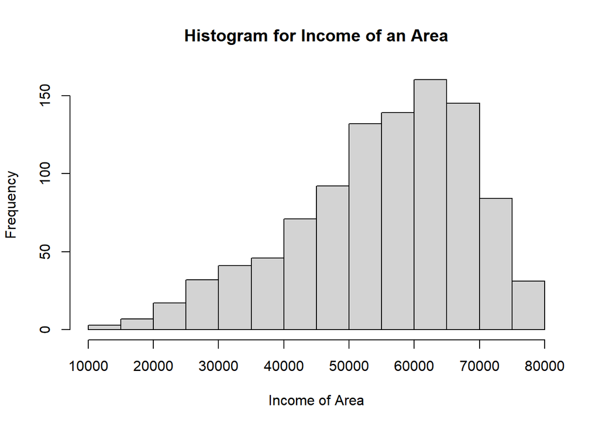

```r
#Histogram of area_income
hist(df$area.income ,xlab ='Income of Area', main ='Histogram for Income of an Area')
```

> * the area income for most online profiles across the different countries is between 50,000/= and 70,000/=

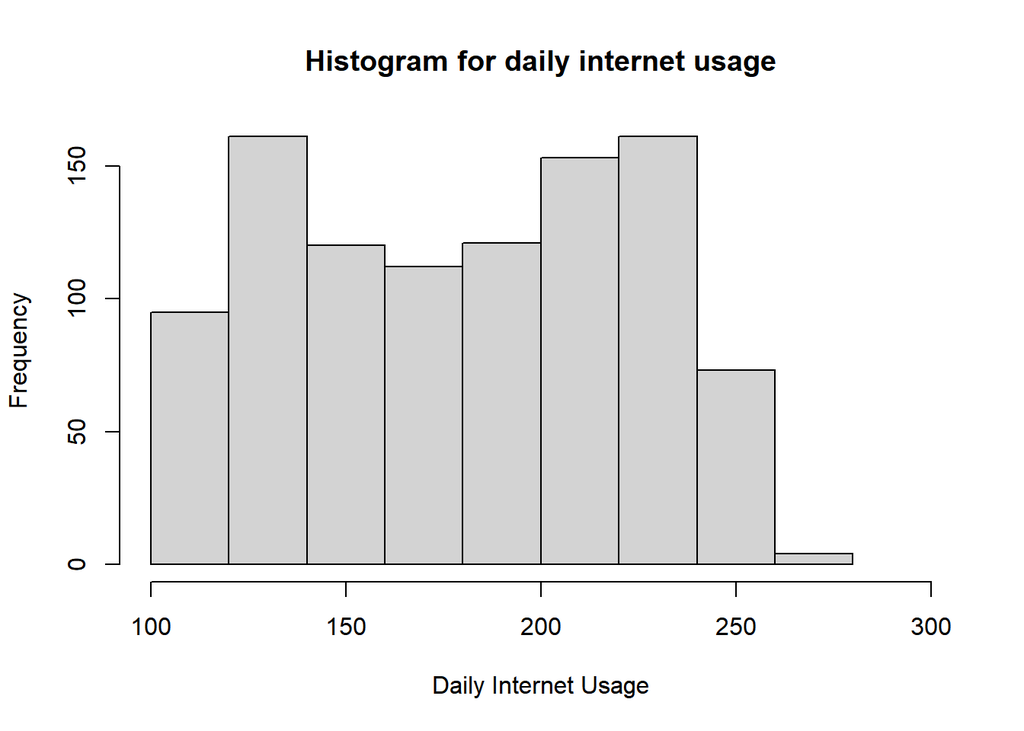

```r
#Histogram of daily_internet_usage
hist(df$daily.internet.usage ,xlim = c(100,300),xlab ='Daily Internet Usage', main ='Histogram for daily internet usage')
```

> * We have a dominant class of internet users between 200 and 245 of the daily internet usage and followed by another class at around 125 of daily internet usage

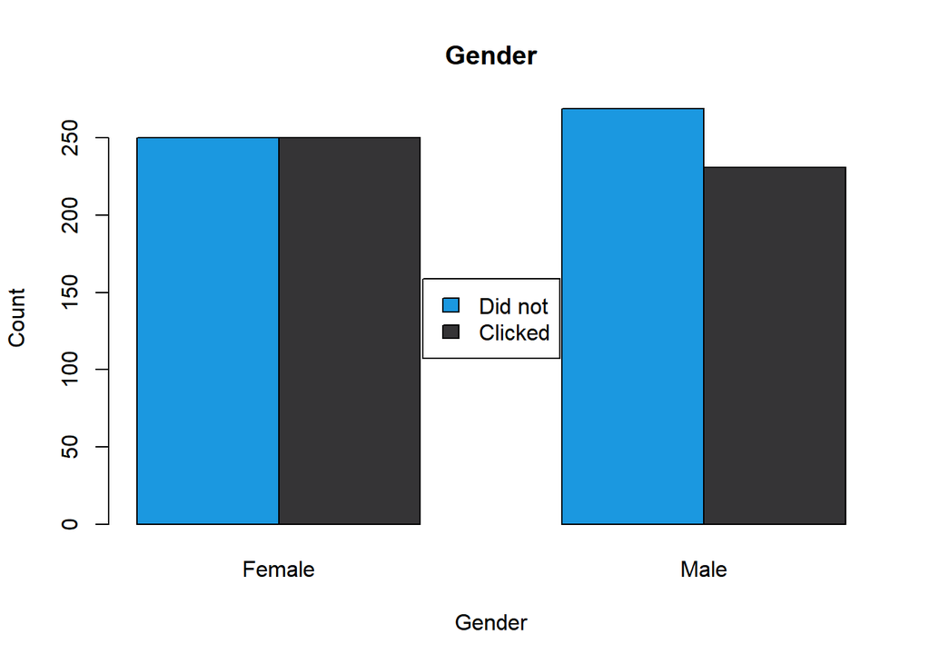

```r
#BarChart for gender
# x-axis values
gender <- table(df[ , c(7, 10)])
# plotting the barplot for gender

barplot(gender,names.arg = c("Female","Male"), beside = TRUE, col = c("#1b98e0", "#353436"), xlab='Gender', ylab ='Count', main = 'Gender')

legend("center",                                    # Add legend to barplot
       legend = c("Did not", "Clicked"),
       fill = c("#1b98e0", "#353436"))
```

> * the bargraph shows that females seems to be well balanced.It is not clear if they are more likely to click on the ad or not.However for the males, they are ‘somewhat’ less likely to click on the ad

```r
# getting the mode for the dataset

# creating the function for mode
getmode <- function(v) {
   uniqv <- unique(v)
   uniqv[which.max(tabulate(match(v, uniqv)))]
}

apply(df,2,getmode)
```

```
##             daily.time.spent.on.site                                  age
##                              "62.26"                                 "31"
##                          area.income                 daily.internet.usage
##                           "61833.90"                             "167.22"
##                        ad.topic.line                                 city
## "Cloned 5thgeneration orchestration"                          "Lisamouth"
##                                 male                              country
##                                  "0"                     "Czech Republic"
##                            timestamp                        clicked.on.ad
##                "2016-03-27 00:53:11"                                  "0"
```

> - The output above shows the various most repeated values for each variable in the data

```r
# getting the median of the variuos numeric variables
apply(df[ , c(1:4, 7, 10)],2,median)
```

```
## daily.time.spent.on.site                      age              area.income
##                   68.215                   35.000                57012.300
##     daily.internet.usage                     male            clicked.on.ad
##                  183.130                    0.000                    0.500
```

> - The above shows the various medians of the numrical variables

```r
# getting the mean of the variuos numeric variables
apply(df[ , c(1:4, 7, 10)],2,mean)
```

```
## daily.time.spent.on.site                      age              area.income
##                  65.0002                  36.0090               55000.0001
##     daily.internet.usage                     male            clicked.on.ad
##                 180.0001                   0.4810                   0.5000
```

> - The above shows the various means of the numrical variables

```r
# getting the range of the variuos numeric variables
apply(df[ , c(1:4, 7, 10)],2,range)
```

```
##      daily.time.spent.on.site age area.income daily.internet.usage male
## [1,]                    32.60  19     13996.5               104.78    0
## [2,]                    91.43  61     79484.8               269.96    1
##      clicked.on.ad
## [1,]             0
## [2,]             1
```

```r
# getting the Inter Quantile Range of the variuos numeric variables
apply(df[ , c(1:4, 7, 10)],2,IQR)
```

```
## daily.time.spent.on.site                      age              area.income
##                  27.1875                  13.0000               18438.8325
##     daily.internet.usage                     male            clicked.on.ad
##                  79.9625                   1.0000                   1.0000
```

```r
# getting the variance of the variuos numeric variables
apply(df[ , c(1:4, 7, 10)],2,var)
```

```
## daily.time.spent.on.site                      age              area.income
##             2.513371e+02             7.718611e+01             1.799524e+08
##     daily.internet.usage                     male            clicked.on.ad
##             1.927415e+03             2.498889e-01             2.502503e-01
```

```r
# getting the standaerd deviation of the variuos numeric variables
apply(df[ , c(1:4, 7, 10)],2,sd)
```

```
## daily.time.spent.on.site                      age              area.income
##             1.585361e+01             8.785562e+00             1.341463e+04
##     daily.internet.usage                     male            clicked.on.ad
##             4.390234e+01             4.998889e-01             5.002502e-01
```

```r
library(moments)
# getting the skewness of the variuos numeric variables
apply(df[ , c(1:4, 7, 10)],2,skewness)
```

```
## daily.time.spent.on.site                      age              area.income
##              -0.37120261               0.47842268              -0.64939670
##     daily.internet.usage                     male            clicked.on.ad
##              -0.03348703               0.07605493               0.00000000
```

> perfroming skewness on the various continuous variables, we find out that * ‘daily.time.spent.on.site’, ‘area.income’ and ‘daily.internet.usage’ variables are negatively skewed and that this indicates that the tail of the distribution is on the left and extends towards more negative values * ‘age’ and ‘male’ variables are positively skewed. This indicates that the tail is on the right side of the distribution, which extends towards more positive values

```r
# getting the kurtosis of the variuos numeric variables
apply(df[ , c(1:4, 7, 10)],2, kurtosis)
```

```
## daily.time.spent.on.site                      age              area.income
##                 1.903942                 2.595482                 2.894694
##     daily.internet.usage                     male            clicked.on.ad
##                 1.727701                 1.005784                 1.000000
```

> - All the continuous variables have a kurtosis less than 3.this implies that it is playkurtic, which means it tends to produce fewer and less extreme outliers than the normal distribution.

```r
library(psych)
describe(df)
```

```
##                          vars    n     mean       sd   median  trimmed      mad
## daily.time.spent.on.site    1 1000    65.00    15.85    68.22    65.74    17.92
## age                         2 1000    36.01     8.79    35.00    35.51     8.90
## area.income                 3 1000 55000.00 13414.63 57012.30 56038.94 13316.62
## daily.internet.usage        4 1000   180.00    43.90   183.13   179.99    58.61
## ad.topic.line*              5 1000   500.50   288.82   500.50   500.50   370.65
## city*                       6 1000   487.32   279.31   485.50   487.51   356.57
## male                        7 1000     0.48     0.50     0.00     0.48     0.00
## country*                    8 1000   116.41    69.94   114.50   115.82    89.70
## timestamp*                  9 1000   500.50   288.82   500.50   500.50   370.65
## clicked.on.ad              10 1000     0.50     0.50     0.50     0.50     0.74
##                               min      max    range  skew kurtosis     se
## daily.time.spent.on.site    32.60    91.43    58.83 -0.37    -1.10   0.50
## age                         19.00    61.00    42.00  0.48    -0.41   0.28
## area.income              13996.50 79484.80 65488.30 -0.65    -0.11 424.21
## daily.internet.usage       104.78   269.96   165.18 -0.03    -1.28   1.39
## ad.topic.line*               1.00  1000.00   999.00  0.00    -1.20   9.13
## city*                        1.00   969.00   968.00  0.00    -1.19   8.83
## male                         0.00     1.00     1.00  0.08    -2.00   0.02
## country*                     1.00   237.00   236.00  0.08    -1.23   2.21
## timestamp*                   1.00  1000.00   999.00  0.00    -1.20   9.13
## clicked.on.ad                0.00     1.00     1.00  0.00    -2.00   0.02
```

> - The above output summarises the univariate analysis for the dataset

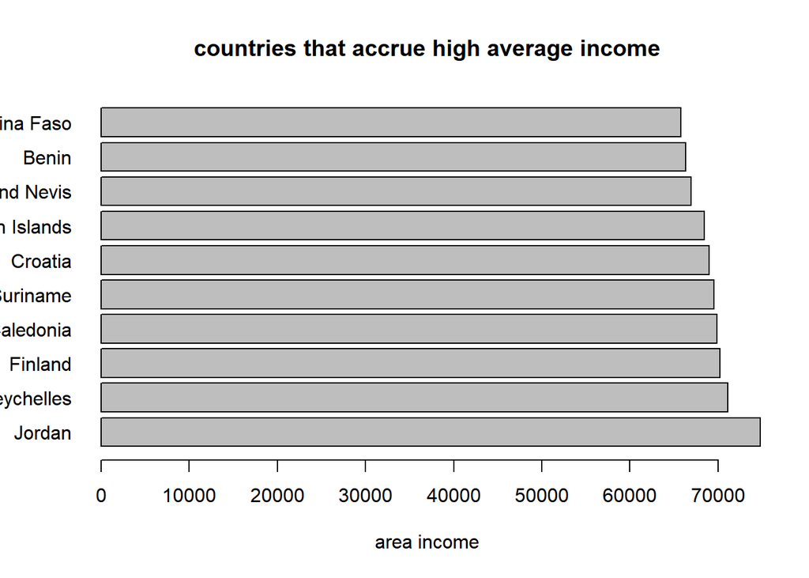

```r
# top 10 countries that accrue high average income

avg.country = aggregate(df$area.income, by=list(df$country), FUN=mean)

cou.top10<-head(avg.country[order(avg.country$x,decreasing = TRUE), ],10)

barplot(cou.top10$x,main = "countries that accrue high average income",
        xlab = "area income",
        #density = 80,
        las=1,
        names=cou.top10$Group.1,
        horiz = TRUE)
```

> * the bargraph shows top 10 countries that accrue high average incomes. the first being Jordan followed by Seychelles and Finland

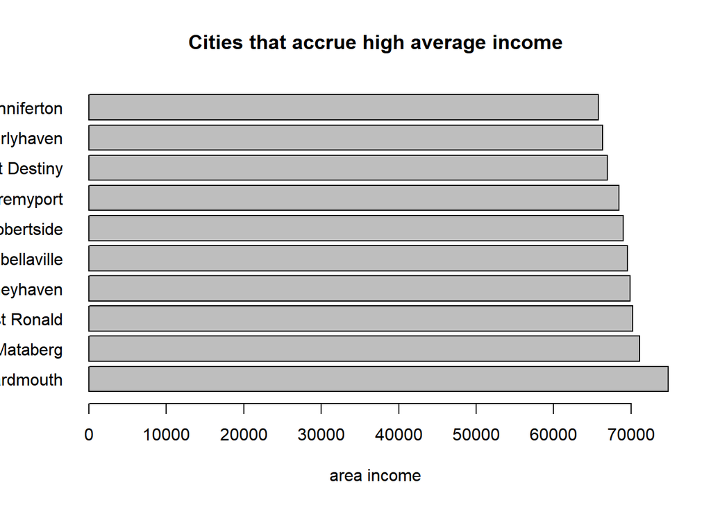

```r
# top 10 cities that accrue high average income

avg.city = aggregate(df$area.income, by=list(df$city), FUN=mean)

city.top10 <- head(avg.city[order(avg.city$x,decreasing = TRUE), ],10)

barplot(cou.top10$x,main = "Cities that accrue high average income",
        xlab = "area income",
        #density = 50,
        las=1,
        names=city.top10$Group.1,
        #col = factor(df$clicked.on.ad),
        #beside = TRUE,
        horiz = TRUE)
```

### Bivariate Analysis

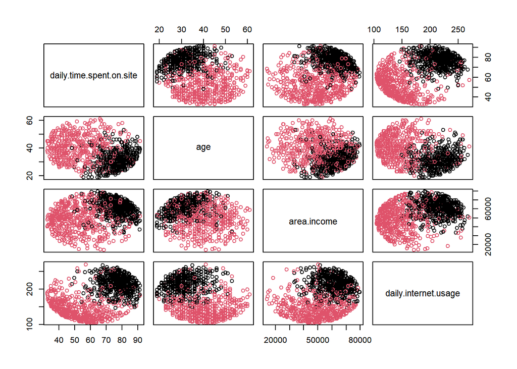

```r
 pairs(~  daily.time.spent.on.site + age + area.income + daily.internet.usage , col = factor(df$clicked.on.ad), data = df)
```

```r
cov(df[ , c(1:4, 10)])
```

```
##                          daily.time.spent.on.site           age   area.income
## daily.time.spent.on.site               251.337095    -46.174146     66130.811
## age                                    -46.174146     77.186105    -21520.926
## area.income                          66130.810908 -21520.925797 179952405.952
## daily.internet.usage                   360.991883   -141.634816    198762.532
## clicked.on.ad                           -5.933143      2.164665     -3195.989
##                          daily.internet.usage clicked.on.ad
## daily.time.spent.on.site            360.99188    -5.9331431
## age                                -141.63482     2.1646647
## area.income                      198762.53153 -3195.9891592
## daily.internet.usage               1927.41540   -17.2740941
## clicked.on.ad                       -17.27409     0.2502503
```

> - As listed above there are varaibles where there are negative and positive covariances.The negative covariances indicate that as one variable increases,the second variable tends to decrease
> - Conversely, the positive covariances indicates the that two variables tend to increase or decrease in tandem.

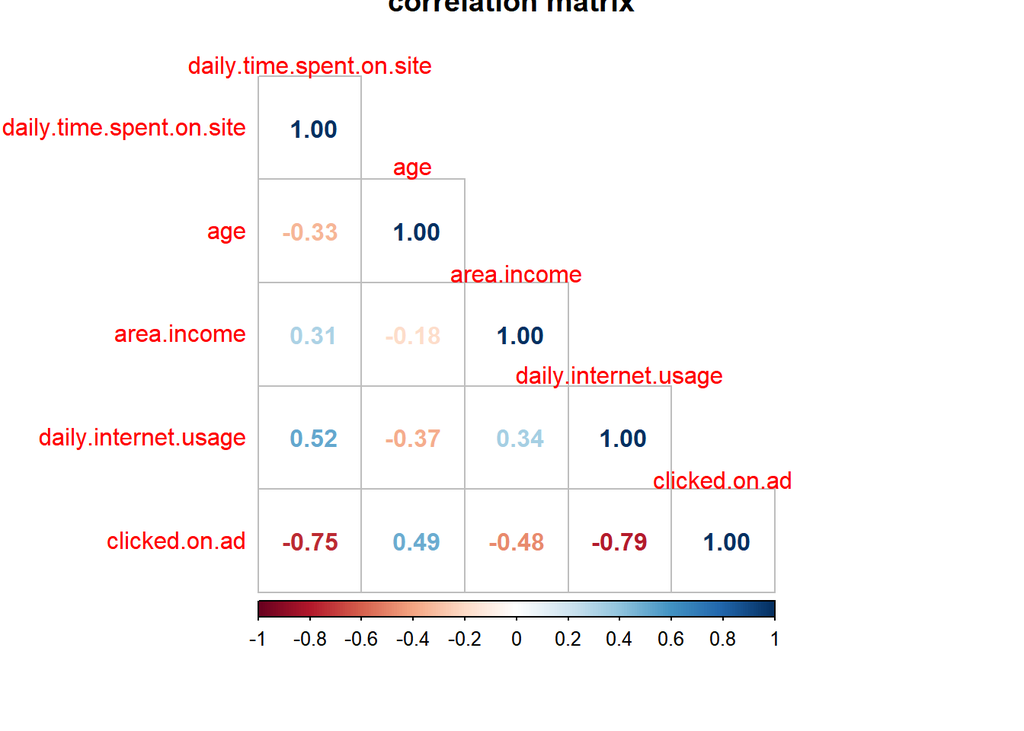

```r
# creating a correlation matrix
library('corrplot')
corrplot(cor(df[ , c(1:4, 10)]), method = 'number',type='lower',tl.srt = 0, main="correlation matrix" )
```

> * The ‘daily internet usage’ and ‘daily time spent on site’ have a negative strong correlation on the ‘click on ad’ variable. * the area income also has a moderate negative correlation on the click on ad variable

```r
# converting the timestamp variable to date type
df$timestamp=as.Date(df$timestamp)
```

### Plotting some timeseries

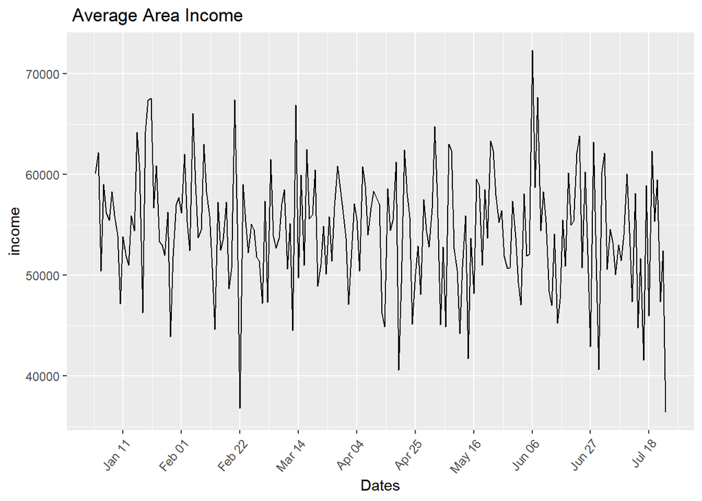

```r
library(ggplot2)
# aggregating based on average income per a given time
#dts <- aggregate(daily.time.spent.on.site ~ timestamp , data=df, mean)

dts <- aggregate(df$area.income, by=list(df$timestamp), FUN=mean)
#create time series plot
p <- ggplot(dts, aes(x=Group.1, y=x)) +
       geom_line()+ scale_x_date(date_labels = "%b %d",date_breaks = "3 week")+ theme(axis.text.x=element_text(angle=50, hjust=1)) + labs(x="Dates", y="income", title=" Average Area Income")

#display time series plot
p
```

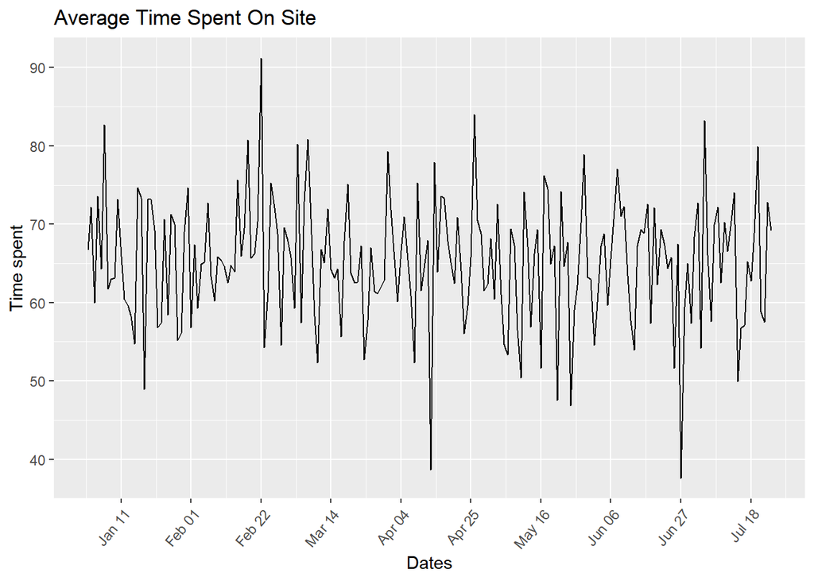

```r
dts <- aggregate(df$daily.time.spent.on.site, by=list(df$timestamp), FUN=mean)
#create time series plot
d <- ggplot(dts, aes(x=Group.1, y=x)) +
       geom_line()+ scale_x_date(date_labels = "%b %d",date_breaks = "3 week")+ theme(axis.text.x=element_text(angle=50, hjust=1))+ labs(x="Dates", y="Time spent", title="Average Time Spent On Site")

#display time series plot
d
```

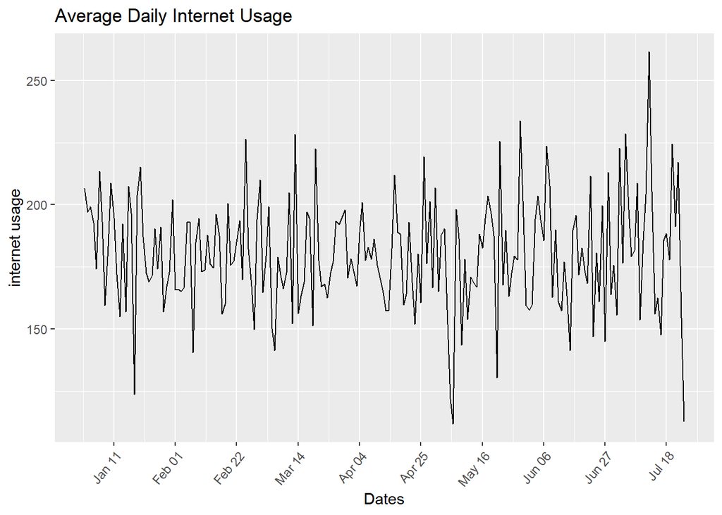

```r
dts <- aggregate(df$daily.internet.usage, by=list(df$timestamp), FUN=mean)
#create time series plot
d <- ggplot(dts, aes(x=Group.1, y=x)) +
       geom_line()+ scale_x_date(date_labels = "%b %d",date_breaks = "3 week")+ theme(axis.text.x=element_text(angle=50, hjust=1)) + labs(x="Dates", y="internet usage", title="Average Daily Internet Usage")

#display time series plot
d
```

## Implementing the solution

```r
# selecting numerical columns
df.n <- df[,c(1:4,7,10)]
head(df.n)
```

```
##   daily.time.spent.on.site age area.income daily.internet.usage male
## 1                    68.95  35    61833.90               256.09    0
## 2                    80.23  31    68441.85               193.77    1
## 3                    69.47  26    59785.94               236.50    0
## 4                    74.15  29    54806.18               245.89    1
## 5                    68.37  35    73889.99               225.58    0
## 6                    59.99  23    59761.56               226.74    1
##   clicked.on.ad
## 1             0
## 2             0
## 3             0
## 4             0
## 5             0
## 6             0
```

```r
library(caTools)
# Splitting data into train
# and test data
#using a splitratio of 70-30
split <- sample.split(df.n, SplitRatio = 0.7)
train_cl <- subset(df.n, split == "TRUE")
test_cl <- subset(df.n, split == "FALSE")

# Feature Scaling
train_scale<-scale(train_cl[-6])
test_scale<-scale(test_cl[-6])
```

```r
# binding back the click on ad variable to the dataset
train_scale<- cbind(train_scale, train_cl[6])
test_scale<- cbind(test_scale, test_cl[6])
head(train_scale)
```

```
##   daily.time.spent.on.site         age area.income daily.internet.usage
## 1               0.21850831 -0.05734908  0.46064986            1.7257647
## 2               0.94091942 -0.52740040  0.96311890            0.3029910
## 3               0.25181095 -1.11496455  0.30492282            1.2785224
## 4               0.55153471 -0.76242606 -0.07373852            1.4928974
## 7               1.49681734 -0.29237474 -0.14622981            0.6360826
## 8               0.02957987  1.47031772 -2.37112603           -1.1127053
##         male clicked.on.ad
## 1 -0.9639723             0
## 2  1.0358212             0
## 3 -0.9639723             0
## 4  1.0358212             0
## 7 -0.9639723             0
## 8  1.0358212             1
```

```r
head(test_scale)
```

```
##    daily.time.spent.on.site          age area.income daily.internet.usage
## 5                 0.2732310 -0.222636231   1.4799817            1.0550230
## 6                -0.2410558 -1.521293253   0.4575549            1.0812952
## 11               -0.9989844  1.292463627  -0.5649169           -1.2904480
## 12                1.1753810 -0.006193394   0.6550760            1.1748332
## 17               -0.5233612 -0.006193394  -2.1349579           -1.1230761
## 18                1.1115554  0.426692279   1.3078280            0.1932504
##          male clicked.on.ad
## 5  -0.9572392             0
## 6   1.0415244             0
## 11 -0.9572392             1
## 12  1.0415244             0
## 17 -0.9572392             1
## 18 -0.9572392             0
```

#### K nearest Neighbours

using the squareroot of n=number of entries is ~31.6… therefore choosing the k as 32

```r
library(caret)
library(class)
# Fitting KNN Model
# to training dataset
classifier_knn <- knn(train = train_scale[-6],
                      test = test_scale[-6],
                      cl = train_scale$clicked.on.ad,
                      k = 32)
```

```r
# Confusiin Matrix
cm <- table(test_scale$clicked.on.ad, classifier_knn)
confusionMatrix(cm)
```

```
## Confusion Matrix and Statistics
##
##    classifier_knn
##       0   1
##   0 158   1
##   1   9 164
##
##                Accuracy : 0.9699
##                  95% CI : (0.9453, 0.9855)
##     No Information Rate : 0.503
##     P-Value [Acc > NIR] : < 2e-16
##
##                   Kappa : 0.9398
##
##  Mcnemar's Test P-Value : 0.02686
##
##             Sensitivity : 0.9461
##             Specificity : 0.9939
##          Pos Pred Value : 0.9937
##          Neg Pred Value : 0.9480
##              Prevalence : 0.5030
##          Detection Rate : 0.4759
##    Detection Prevalence : 0.4789
##       Balanced Accuracy : 0.9700
##
##        'Positive' Class : 0
##
```

#### Naive Bayes

```r
# Loading package
library(e1071)
library(caTools)
library(caret)
# Fitting Naive Bayes Model
# to training dataset
set.seed(120)  # Setting Seed
bayes <- naiveBayes(clicked.on.ad ~ ., data = train_scale)
```

```r
# Predicting on test data'
y_pred <- predict(bayes, newdata = test_scale)

# Confusion Matrix
cm <- table(test_scale$clicked.on.ad, y_pred)

# Model Evauation
confusionMatrix(cm)
```

```
## Confusion Matrix and Statistics
##
##    y_pred
##       0   1
##   0 154   5
##   1   3 170
##
##                Accuracy : 0.9759
##                  95% CI : (0.9531, 0.9895)
##     No Information Rate : 0.5271
##     P-Value [Acc > NIR] : <2e-16
##
##                   Kappa : 0.9517
##
##  Mcnemar's Test P-Value : 0.7237
##
##             Sensitivity : 0.9809
##             Specificity : 0.9714
##          Pos Pred Value : 0.9686
##          Neg Pred Value : 0.9827
##              Prevalence : 0.4729
##          Detection Rate : 0.4639
##    Detection Prevalence : 0.4789
##       Balanced Accuracy : 0.9762
##
##        'Positive' Class : 0
##
```

#### Random Forest

```r
library(randomForest)
# Fitting Random Forest to the train dataset
set.seed(0)  # Setting seed
classifier_RF = randomForest(x = train_scale[-6],
                             y = train_scale[, 6],
                             ntree = 500)
# Predicting the Test set results
y_pred = predict(classifier_RF, newdata = test_scale[-6])

# Confusion Matrix
cm <- table(test_scale[, 6], y_pred)

# Model Evauation
#confusionMatrix(cm)
```

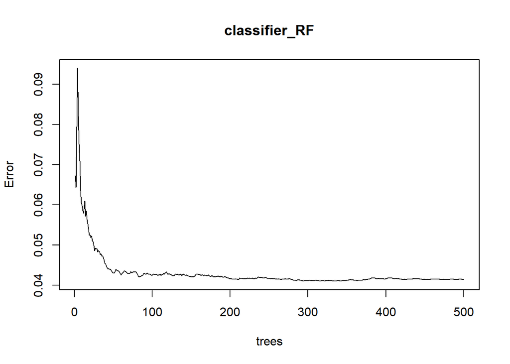

```r
# Plotting model
plot(classifier_RF)
```

getting an optimum number of trees as ~60 trees

```r
# Importance plot
importance(classifier_RF)
```

```
##                          IncNodePurity
## daily.time.spent.on.site    45.9752866
## age                         18.9290168
## area.income                 18.4516242
## daily.internet.usage        53.8425721
## male                         0.8170262
```

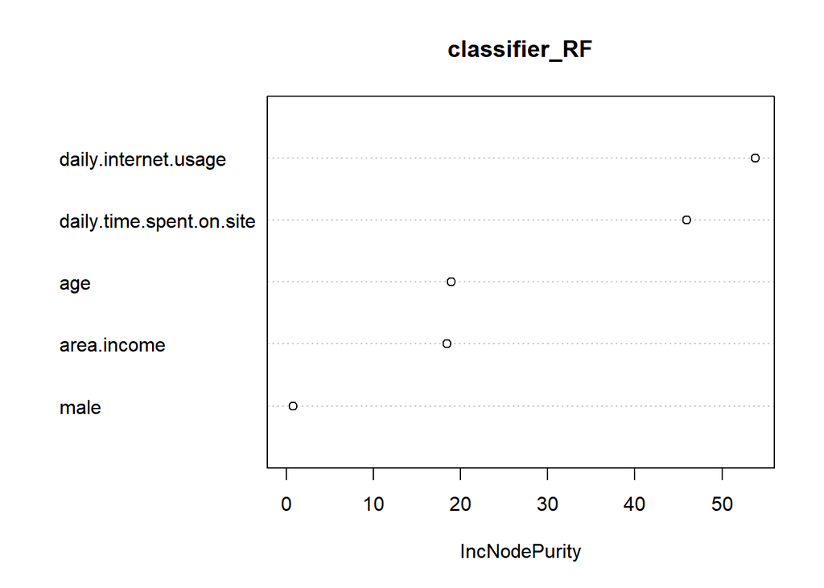

```r
# Variable importance plot
varImpPlot(classifier_RF)
```

the above shows the most important numerical columns that determine if an individual clicked on the site or not

#### Support Vector Machines

```r
library(e1071)

classifier_linear = svm(formula = clicked.on.ad ~ .,
                 data = train_scale,
                 type = 'C-classification',
                 kernel = 'linear')
```

```r
# Predicting the Test set results
y_pred = predict(classifier_linear, newdata = test_scale)
```

```r
# Confusion Matrix
cm <- table(test_scale$clicked.on.ad, y_pred)

# Model Evauation
confusionMatrix(cm)
```

```
## Confusion Matrix and Statistics
##
##    y_pred
##       0   1
##   0 156   3
##   1   3 170
##
##                Accuracy : 0.9819
##                  95% CI : (0.9611, 0.9933)
##     No Information Rate : 0.5211
##     P-Value [Acc > NIR] : <2e-16
##
##                   Kappa : 0.9638
##
##  Mcnemar's Test P-Value : 1
##
##             Sensitivity : 0.9811
##             Specificity : 0.9827
##          Pos Pred Value : 0.9811
##          Neg Pred Value : 0.9827
##              Prevalence : 0.4789
##          Detection Rate : 0.4699
##    Detection Prevalence : 0.4789
##       Balanced Accuracy : 0.9819
##
##        'Positive' Class : 0
##
```

## Challenging The Solution

> - Further analysirands would help define a better potential customer profile.
> - Having further analysis on the timestamp variable such as the time aspect would aid in getting more insights .
> - Furthermore, grouping the topics from the ad topic variable so as to be able to properly analyse. and get better insights
> - encoding the the sring variables and include in the models to check if the accuracy scores can be improved
> - carry out more hyperparameter tuning using grid on the models